# PS5-ggplot

tiff

2023-02-17

**Part 1 - Load and Check Data:**

**Question 1**

```r
library(tidyverse)

gapminder <- read_delim("data/gapminder.csv.bz2")
```

**Question 2**

```r
nrow(gapminder)
```

```
## [1] 13055
```

```r
ncol(gapminder)
```

```
## [1] 25
```

The data contains 13055 observations and has 25 variables.

**Question3**

```r
gapminder %>%
  sample_n(5) %>%
  knitr::kable()
```

| iso3 | name | iso2 | region | sub-region | intermediate-region | time | totalPopulation | fertilityRate | lifeExpectancy | childMortality | youthFemaleLiteracy | youthMaleLiteracy | adultLiteracy | GDP_PC | accessElectricity | agriculturalLand | agricultureTractors | cerealProduction | fertilizerHa | co2 | greenhouseGases | co2_PC | pm2.5_35 | battleDeaths |
| --- | --- | --- | --- | --- | --- | --- | --- | --- | --- | --- | --- | --- | --- | --- | --- | --- | --- | --- | --- | --- | --- | --- | --- | --- |
| IRL | Ireland | IE | Europe | Northern Europe | NA | 1973 | 3085950 | 3.710 | 71.34556 | 21.1 | NA | NA | NA | 14093.170 | NA | 56820 | 98300 | 1296500 | 393.25799 | 22860.08 | 50501.47 | 7.40779 | NA | NA |
| ZAF | South Africa | ZA | Africa | Sub-Saharan Africa | Southern Africa | 1984 | 31841588 | 4.792 | 60.35300 | 74.8 | NA | NA | NA | 6527.407 | NA | 940330 | 170000 | 7927492 | 77.96463 | 315948.72 | NA | 9.92252 | NA | NA |
| OMN | Oman | OM | Asia | Western Asia | NA | 2000 | 2267973 | 3.716 | 72.12600 | 16.4 | NA | NA | NA | 18698.500 | 100 | 11730 | 180 | 33163 | 185.67742 | 21690.31 | 35439.11 | 9.56374 | 98.38022 | NA |
| NRU | Nauru | NR | Oceania | Micronesia | NA | 1963 | 5275 | NA | NA | NA | NA | NA | NA | NA | NA | 3 | NA | NA | NA | NA | NA | NA | NA | NA |
| BLR | Belarus | BY | Europe | Eastern Europe | NA | 1985 | 9975000 | 2.090 | 70.99268 | 17.6 | NA | NA | NA | NA | NA | NA | NA | NA | NA | NA | 183139.30 | NA | NA | NA |

*The sample looks good, there are some missing values “NA”, but the data is organized,* *clear, and the observations makes sense with the variable.*

**Part 2 - Descriptive Statistics:**

**Question 1**

```r
gapminder %>%
  select(iso3, iso2, name) %>%
  summarise( iso3 = length(unique(iso3)),
            iso2 = length(unique(iso2)),
            name = length(unique(name)))
```

```
## # A tibble: 1 × 3
##    iso3  iso2  name
##   <int> <int> <int>
## 1   253   249   250
```

**Question 2 Part A**

```r
gapminder %>%
  group_by(iso2) %>%
  summarise(iso2code = n_distinct(name)) %>%
  arrange(desc(iso2code))
```

```
## # A tibble: 249 × 2
##    iso2  iso2code
##    <chr>    <int>
##  1 <NA>         2
##  2 AD           1
##  3 AE           1
##  4 AF           1
##  5 AG           1
##  6 AI           1
##  7 AL           1
##  8 AM           1
##  9 AO           1
## 10 AQ           1
## # … with 239 more rows
```

**Question 2 Part B**

```r
gapminder %>%
  group_by(name) %>%
  summarise(iso3code = n_distinct(iso3)) %>%
  arrange(desc(iso3code))
```

```
## # A tibble: 250 × 2
##    name                iso3code
##    <chr>                  <int>
##  1 <NA>                       4
##  2 Afghanistan                1
##  3 Albania                    1
##  4 Algeria                    1
##  5 American Samoa             1
##  6 Andorra                    1
##  7 Angola                     1
##  8 Anguilla                   1
##  9 Antarctica                 1
## 10 Antigua and Barbuda        1
## # … with 240 more rows
```

**Question 3**

```r
gapminder %>%
  filter(!is.na (time)) %>%
  select(time) %>%
  summarise( minimum_year = min(time), maximum_year = max(time))
```

```
## # A tibble: 1 × 2
##   minimum_year maximum_year
##          <dbl>        <dbl>
## 1         1960         2019
```

**Part 3 - CO2 Emissions:**

**Question 1**

```r
gapminder %>%
  group_by(time) %>%
  filter(is.na(co2), is.na(co2_PC)) %>%
  count() %>%
  arrange(desc(n))
```

```
## # A tibble: 61 × 2
## # Groups:   time [61]
##     time     n
##    <dbl> <int>
##  1  2017   217
##  2  2018   217
##  3  2019   217
##  4  1960    60
##  5  1961    60
##  6  1962    58
##  7  1963    57
##  8  1964    51
##  9  1965    51
## 10  1966    51
## # … with 51 more rows
```

*(different variables, same numbers for the Co2 and Co2_PC)* When looking at Co2 and CO2 PC seperately they still produced the same numbers that can be seen under the variable n in the data above.

**Question 2**

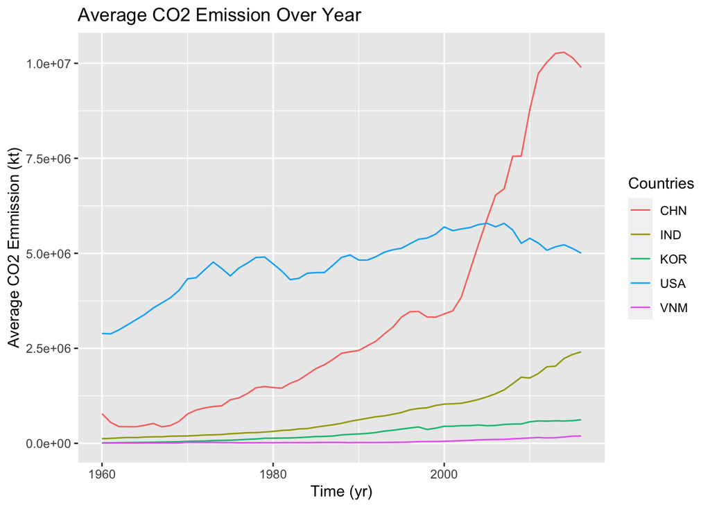

```r
total_CO2<- gapminder %>%
  group_by(iso3, time) %>%
  filter(co2 != "NA", name != "NA") %>%
  summarise(avgCO2 = mean(co2)) %>%
  filter(iso3 == "USA" | iso3 == "CHN" | iso3 == "IND" | iso3 == "VNM" | iso3 == "KOR")



total_CO2 %>%
  ggplot(aes(time, avgCO2, col = factor(iso3))) +
  geom_line() +
  labs(x = "Time (yr)", y = "Average CO2 Emmission (kt)", col = "Countries",
       title = "Average CO2 Emission Over Year")
```

**Question 3**

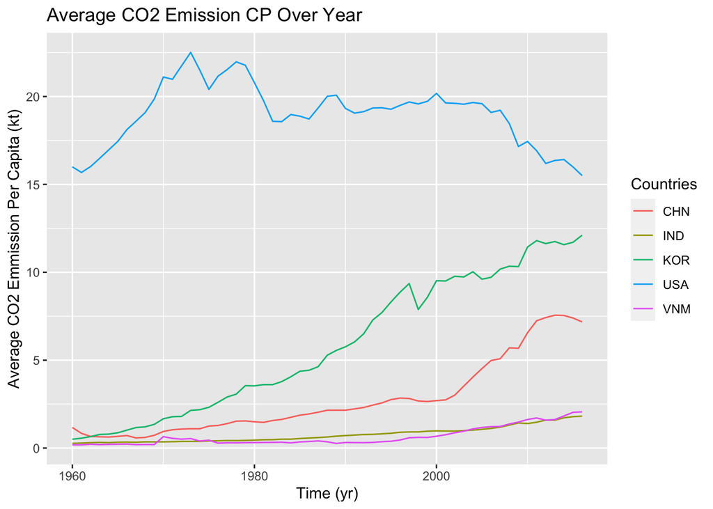

```r
percapita <- gapminder %>%
  group_by(iso3, time) %>%
  filter(co2_PC != "NA", name != "NA") %>%
  summarise(avgcapita = mean(co2_PC)) %>%
  filter(iso3 == "USA" | iso3 == "CHN" | iso3 == "IND" | iso3 == "VNM" | iso3 == "KOR")


percapita %>%
  ggplot(aes(time, avgcapita, col = factor(iso3))) +
  geom_line() +
  labs(x = "Time (yr)", y = "Average CO2 Emmission Per Capita (kt)", col = "Countries",
       title = "Average CO2 Emission CP Over Year")
```

**Question 4**

```r
gapminder %>%
  group_by(region, time) %>%
  filter(time == 1960 | time ==2016) %>%
  filter(co2_PC != "NA", region !="NA") %>%
  summarise(avgCO2_PC = mean(co2_PC))
```

```
## # A tibble: 10 × 3
## # Groups:   region [5]
##    region    time avgCO2_PC
##    <chr>    <dbl>     <dbl>
##  1 Africa    1960     0.291
##  2 Africa    2016     1.20
##  3 Americas  1960     7.15
##  4 Americas  2016     4.80
##  5 Asia      1960     1.74
##  6 Asia      2016     6.47
##  7 Europe    1960     5.77
##  8 Europe    2016     6.64
##  9 Oceania   1960     2.73
## 10 Oceania   2016     4.57
```

Looking at he the average CO2 emission per capita for each continent, the data shows that in Africa, Asia, Europe, and Oceania the average Co2 PC increased from 1960 to 2016. However, in the Americas, the average CO2 PC actually decreased from 2960 to 2016.

**Question 5**

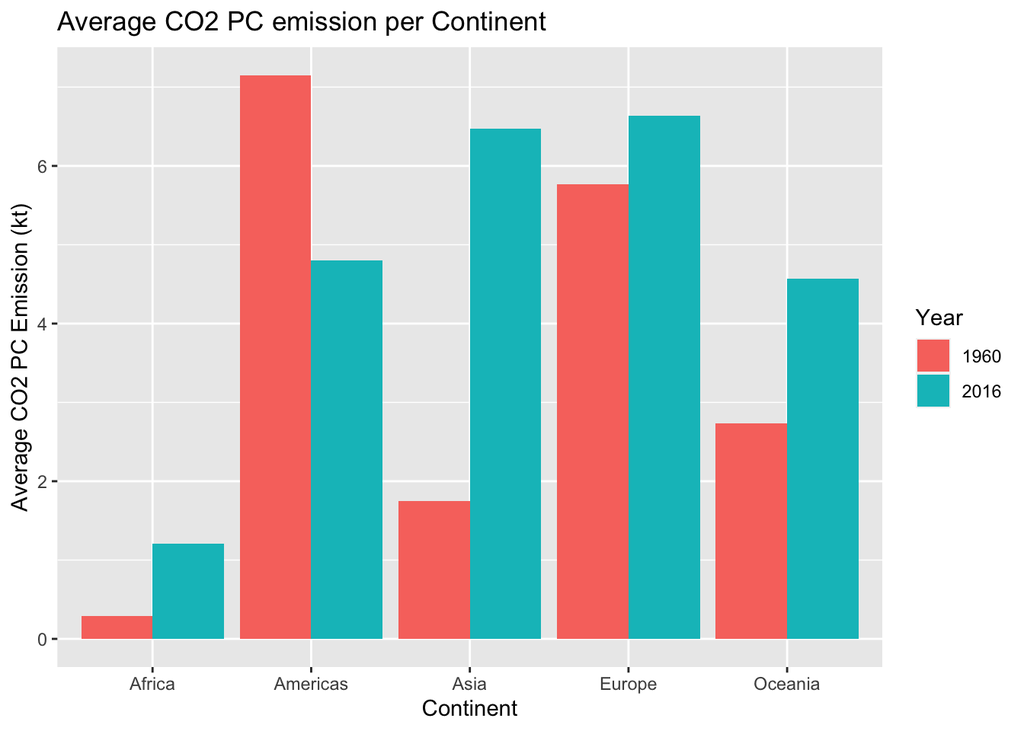

```r
gapminder %>%
  group_by(region, time) %>%
  filter(time == 1960 | time == 2016) %>%
  filter(co2_PC != "NA", region !="NA") %>%
  summarise(avgCO2_PC = unique(mean(co2_PC))) %>%

  ggplot() +
  geom_col(aes(x = region, y = avgCO2_PC, fill = factor(time)), position = "dodge") +
  labs(title = "Average CO2 PC emission per Continent",
           x = "Continent", y = "Average CO2 PC Emission (kt)", fill = "Year")
```

The bar chart suggests that in Africa, Asia, Europe, and Oceania the average CO2 emission per-capita were higher in 2016 than compared to 1960. However, in the Americas, average CO2 emission per-capita was lower than it was in 1960.

**Question 6**

```r
gapminder %>%
  group_by(region) %>%
  filter(time == 2016) %>%
  filter(name != "NA", co2_PC != "NA", region != "NA") %>%
  select(name, co2_PC) %>%
  filter(rank(co2_PC) < 4 | rank(desc(co2_PC)) < 4) %>%
  arrange(region, co2_PC)
```

```
## # A tibble: 30 × 3
## # Groups:   region [5]
##    region   name                               co2_PC
##    <chr>    <chr>                               <dbl>
##  1 Africa   Congo, Democratic Republic of the  0.0256
##  2 Africa   Somalia                            0.0455
##  3 Africa   Burundi                            0.0472
##  4 Africa   Seychelles                         6.39
##  5 Africa   Libya                              7.79
##  6 Africa   South Africa                       8.48
##  7 Americas Haiti                              0.275
##  8 Americas Nicaragua                          0.887
##  9 Americas Honduras                           1.06
## 10 Americas Canada                            15.1
## # … with 20 more rows
```

*The year 2019 does not work for this problem,* *I had to switch the year to 2016, and had checked with other TAs during their OH*

**Part 4 - GDP Per Capita:**

**Question 1**

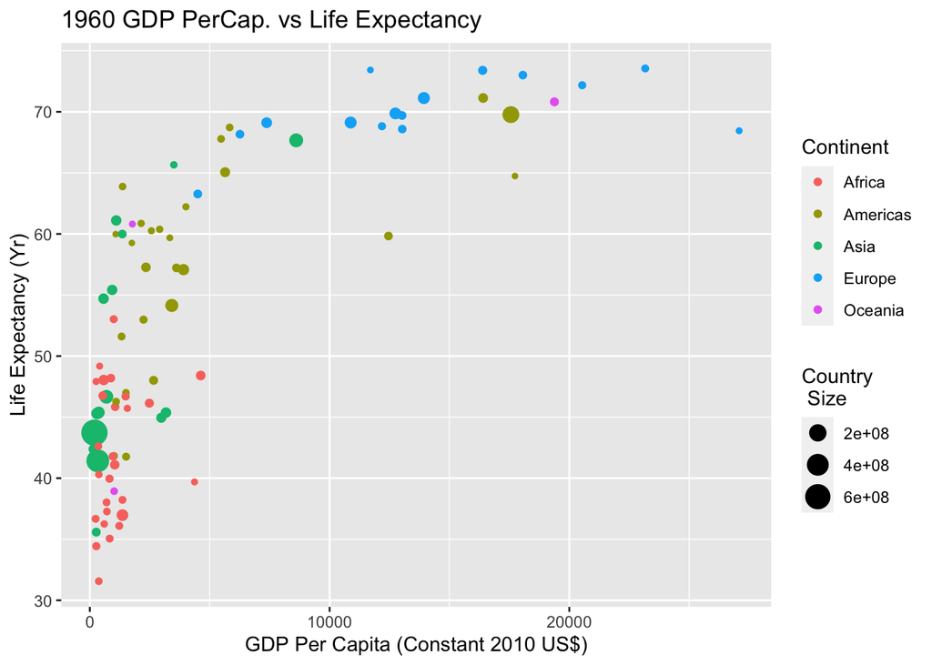

```r
gapminder %>%
  group_by(name) %>%
  select(region, time, GDP_PC, lifeExpectancy, totalPopulation) %>%
  filter(time == 1960) %>%
  filter(GDP_PC != "NA", lifeExpectancy != "NA", name != "NA", totalPopulation != "NA") %>%
  ggplot() +
  geom_point(aes(GDP_PC, lifeExpectancy, color = region, size = totalPopulation)) +
  labs(title = "1960 GDP PerCap. vs Life Expectancy", x = "GDP Per Capita (Constant 2010 US$)",
       y = "Life Expectancy (Yr)", color ="Continent", size = "Country \n Size")
```

The scatter plot suggests that as GDP Per Capita increases, so does the life expectancy. Additionally, the plot depicts where continents are on the scale. For instance, we can see that Africa is towards the left end with lower life expectancy and lower GDP CP while Europe is on the right side of the plot with higher life expectancy and higher GDP CP. It also specifies how large a country is by the size of the dot. Larger dot indicates a larger country and smaller dot indicates a smaller country.

**Question 2**

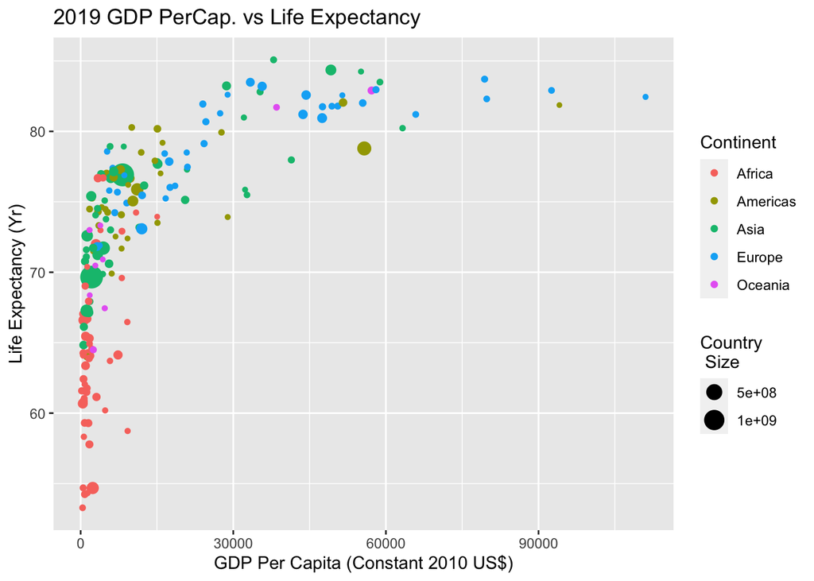

```r
gapminder %>%
  group_by(name) %>%
  select(region, time, GDP_PC, lifeExpectancy, totalPopulation) %>%
  filter(time == 2019) %>%
  filter(GDP_PC != "NA", lifeExpectancy != "NA", name != "NA", totalPopulation != "NA") %>%
  ggplot() +
  geom_point(aes(GDP_PC, lifeExpectancy, color = region, size = totalPopulation)) +
  labs(title = "2019 GDP PerCap. vs Life Expectancy", x = "GDP Per Capita (Constant 2010 US$)",
       y = "Life Expectancy (Yr)", color ="Continent", size = "Country \n Size")
```

The scatter plot suggests that there are many countries with low GDP PC but high Life Expectancy. Also, that some countries from Europe, Asia, Oceania, and Americas have the highest GDP PC and highest life expectancy, although that does not apply to all countries. Many to all of countries in Africa have some of the lowest GDP PC compared to others.

**Question 3**

Comparing the two plots, from 1960 to 2019, there has definetly been a shift in the gap between GDP CP and life expectancy in countries. More countries have greater life expectancy, and there seem to be less of a gap between countries. For instance, in 1960, Europe was dominatly in the lead, however in 2019, although there is still a gap for some European countries, more countries in Asia and Americas can compare to Europe. Lastly, in 2019 there are more dots in the scatter plot compared to the scatter plot of 1960 indicating that there are more countries being included into the data.

**Question 4**

```r
gapminder %>%
  group_by(region, time) %>%
  select(lifeExpectancy, time) %>%
  filter(lifeExpectancy !="NA", region != "NA") %>%
  filter(time == 1960 | time == 2019) %>%
  summarise(avg_life_exp_reg = (mean(lifeExpectancy)))
```

```
## # A tibble: 10 × 3
## # Groups:   region [5]
##    region    time avg_life_exp_reg
##    <chr>    <dbl>            <dbl>
##  1 Africa    1960             41.5
##  2 Africa    2019             64.1
##  3 Americas  1960             58.6
##  4 Americas  2019             75.8
##  5 Asia      1960             51.6
##  6 Asia      2019             74.6
##  7 Europe    1960             68.3
##  8 Europe    2019             79.4
##  9 Oceania   1960             56.4
## 10 Oceania   2019             73.5
```

Yes, the results fit the figures. In the scatter plots, we can see a general shift in countries having an increase in life expectancy and looking at the data, each continent from 1960 to 2019 has an increase in their average life expectancy.

**Question 5**

```r
gapminder %>%
  select(region, lifeExpectancy, time) %>%
  filter(!is.na(lifeExpectancy), !is.na(region)) %>%
  filter(time == 1960 | time == 2019) %>%
  group_by(region, time) %>%
  summarise(avg_exp = mean(lifeExpectancy)) %>%
  summarise(prev = lag(avg_exp),
         growth = avg_exp - prev) %>%
  filter(!is.na(prev), !is.na(growth)) %>%
  arrange(desc(growth))
```

```
## # A tibble: 5 × 3
## # Groups:   region [5]
##   region    prev growth
##   <chr>    <dbl>  <dbl>
## 1 Asia      51.6   23.0
## 2 Africa    41.5   22.6
## 3 Americas  58.6   17.2
## 4 Oceania   56.4   17.1
## 5 Europe    68.3   11.1
```

What the data is showing us is the growth of the average life expectancy in each continent from 1960 to 2019. Taking the mean of the average life expectancy in each continent and finding the difference between the two years.

**Question 6**

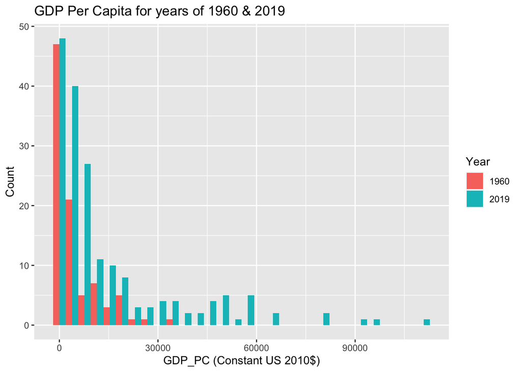

```r
gapminder %>%
  filter(time == 1960 | time == 2019) %>%
  filter(!is.na(region), !is.na (name), !is.na(GDP_PC)) %>%
  ggplot() +
  geom_histogram(aes(GDP_PC, fill = factor(time)), position = "dodge") +
  labs(title = "GDP Per Capita for years of 1960 & 2019", x = "GDP_PC (Constant US 2010$)",
       y = "Count", fill = "Year")
```

The histogram above is showing us how many countries had what GDP per capita for the the years of 1960 (red) and 2019 (blue). We can see that a majority of countries had a GDP PC of under 20,000 in both 1960 and 2019, with few having GCP PC over 30,000. Under 5 countries had GDP PC over 30,000 in 1960 but there are around 40 countries with a GDP PC of over 30,000 in 2019.

**Question 7**

```r
gapminder %>%
  select(name, time, lifeExpectancy) %>%
  filter(!is.na(time), !is.na(lifeExpectancy), !is.na(name)) %>%
  filter(time == 1960) %>%
  mutate(ranking = rank(desc(lifeExpectancy))) %>%
  arrange(desc(rank(lifeExpectancy))) %>%
  filter(name == "United States of America")
```

```
## # A tibble: 1 × 4
##   name                      time lifeExpectancy ranking
##   <chr>                    <dbl>          <dbl>   <dbl>
## 1 United States of America  1960           69.8      17
```

```r
gapminder %>%
  select(name, time, lifeExpectancy) %>%
  filter(!is.na(time), !is.na(lifeExpectancy), !is.na(name)) %>%
  filter(time == 2019 ) %>%
  mutate(ranking = rank(desc(lifeExpectancy))) %>%
  arrange(desc(rank(lifeExpectancy))) %>%
  filter(name == "United States of America")
```

```
## # A tibble: 1 × 4
##   name                      time lifeExpectancy ranking
##   <chr>                    <dbl>          <dbl>   <dbl>
## 1 United States of America  2019           78.8      46
```

**Question 8**

```r
gapminder %>%
  select(name, time, lifeExpectancy) %>%
  filter(!is.na(time), !is.na(lifeExpectancy), !is.na(name)) %>%
  filter(time == 1960) %>%
  mutate(ranking = rank(desc(lifeExpectancy))) %>%
  filter(name == "United States of America") %>%
  mutate(adjusted = ranking/188)
```

```
## # A tibble: 1 × 5
##   name                      time lifeExpectancy ranking adjusted
##   <chr>                    <dbl>          <dbl>   <dbl>    <dbl>
## 1 United States of America  1960           69.8      17   0.0904
```

```r
gapminder %>%
  select(name, time, lifeExpectancy) %>%
  filter(!is.na(time), !is.na(lifeExpectancy), !is.na(name)) %>%
  filter(time == 2019) %>%
  mutate(ranking = rank(desc(lifeExpectancy))) %>%
  filter(name == "United States of America") %>%
  mutate(adjusted = (ranking/196))
```

```
## # A tibble: 1 × 5
##   name                      time lifeExpectancy ranking adjusted
##   <chr>                    <dbl>          <dbl>   <dbl>    <dbl>
## 1 United States of America  2019           78.8      46    0.235
```

*For this Assignment, I spent a total of 9 hours solving the problems*